# Relatorio Parcial 1

Daniel Barbosa

Criando modelos para os dados

Author

Lucas Castanheira e José Guilherme - FitoData

Published

September 9, 2024

# Introdução

Os dados coletados da severidade (Escala Davis) e da contagem de plantas atacadas não seguem uma distribuição normal - conforme visto no gráfico abaixo. A melhor distribuição que se aplica ao dados é a distribuição de Poisson, que segue o seguinte modelo não linear log μ = β0+β1x .

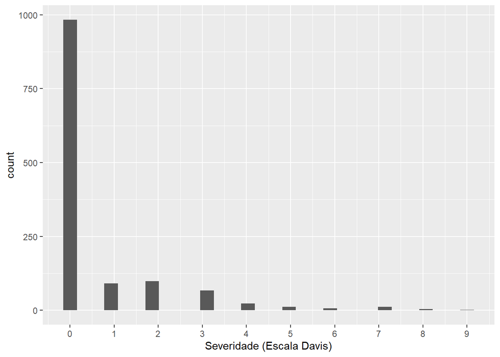

Figura 1: Distribuição das observações do nível de severidade pela Escala Davis.

Para ajustar essa curva, criamos modelos lineares generalizados a fim de encontrar o modelo que melhor se adapte aos resultados, levando em consideração critérios como residual deviance e o AIC.

Estamos em fase de leitura e processamento para achar o melhor modelo que se ajuste aos seus dados.

Abaixo montamos um exemplo de como temos feito esse processo.

# Estatística

A fim de encontrar o modelo ideal, criamos modelos com diferentes níveis de complexidade para compará-los e verificar se há diferença entre eles. No fim das contas, queremos ficar com o modelo mais simples, desde que ele explique os dados da mesma forma que os mais complexos.

Para isso, seguimos os seguintes passos:

## 1) Elaborar modelos com diferentes níveis de complexidade

Estamos utilizando os dados de severidade medido pela Escala Davis. Pare esse exemplo, utilizamos apenas as observações feitas no dia “3DAA”.

- Modelo:
  - Completo (Severidade ~ taxa_aplicacao_esc * Adjuvante + (1 | Bloco);
  - Sem interação (Severidade ~ taxa_aplicacao_esc + Adjuvante + (1 | Bloco);
  - Apenas a Taxa (Severidade ~ taxa_aplicacao_esc + (1 | Bloco);
  - Apenas o Ajuvante (Severidade ~ Adjuvante + (1 | Bloco);

## 2) Comparação entre modelos

Utilizamos o Critério de Informação de Akaike (AIC) para comparar os modelos criados.

Quanto menor o AIC, melhor é o modelo.

```
            Modelo     AICc
1         Completo 3440.891
2    Sem Interação 3442.976
4 Apenas Adjuvante 3452.286
3      Apenas Taxa 3452.298
```

## 3) Tomada de decisão

Pelo resultado acima, vemos que o modelo completo é o que melhor representa os dados. Por isso, seguimos com ele.

Abaixo temos as informações gerais abstraídas dele, das quais tiraremos nossas conclusões.

```
Generalized linear mixed model fit by maximum likelihood (Laplace
  Approximation) [glmerMod]
 Family: poisson  ( log )
Formula: Severidade ~ taxa_aplicacao_esc * Adjuvante + (1 | Bloco)
   Data: df_3DAA_A_Davis

     AIC      BIC   logLik deviance df.resid
  3440.6   3512.9  -1706.3   3412.6     1285

Scaled residuals:
    Min      1Q  Median      3Q     Max
-0.9884 -0.8283 -0.7240 -0.6138 10.5883

Random effects:
 Groups Name        Variance Std.Dev.
 Bloco  (Intercept) 0.01587  0.126
Number of obs: 1299, groups:  Bloco, 4

Fixed effects:
                                                     Estimate Std. Error
(Intercept)                                          -0.10681    0.21008
taxa_aplicacao_esc-0.815130208194049                 -0.21592    0.23200
taxa_aplicacao_esc-0.399730388482762                 -0.48103    0.24079
taxa_aplicacao_esc1.46956880021803                   -0.16255    0.16484
AdjuvanteNA                                          -0.12434    0.16631
AdjuvanteOchima                                       0.07501    0.15812
AdjuvanteSilwet                                      -0.58273    0.19027
taxa_aplicacao_esc-0.815130208194049:AdjuvanteNA     -0.35947    0.25206
taxa_aplicacao_esc-0.399730388482762:AdjuvanteNA     -0.13042    0.26214
taxa_aplicacao_esc-0.815130208194049:AdjuvanteOchima -0.02166    0.22726
taxa_aplicacao_esc-0.399730388482762:AdjuvanteOchima -0.09303    0.24698
taxa_aplicacao_esc-0.815130208194049:AdjuvanteSilwet  0.28125    0.26150
taxa_aplicacao_esc-0.399730388482762:AdjuvanteSilwet  0.68449    0.26485
                                                     z value Pr(>|z|)
(Intercept)                                           -0.508  0.61115
taxa_aplicacao_esc-0.815130208194049                  -0.931  0.35202
taxa_aplicacao_esc-0.399730388482762                  -1.998  0.04575 *
taxa_aplicacao_esc1.46956880021803                    -0.986  0.32409
AdjuvanteNA                                           -0.748  0.45469
AdjuvanteOchima                                        0.474  0.63523
AdjuvanteSilwet                                       -3.063  0.00219 **
taxa_aplicacao_esc-0.815130208194049:AdjuvanteNA      -1.426  0.15383
taxa_aplicacao_esc-0.399730388482762:AdjuvanteNA      -0.498  0.61882
taxa_aplicacao_esc-0.815130208194049:AdjuvanteOchima  -0.095  0.92409
taxa_aplicacao_esc-0.399730388482762:AdjuvanteOchima  -0.377  0.70640
taxa_aplicacao_esc-0.815130208194049:AdjuvanteSilwet   1.076  0.28213
taxa_aplicacao_esc-0.399730388482762:AdjuvanteSilwet   2.584  0.00975 **
---
Signif. codes:  0 '***' 0.001 '**' 0.01 '*' 0.05 '.' 0.1 ' ' 1
fit warnings:
fixed-effect model matrix is rank deficient so dropping 3 columns / coefficients
```

## 4) Grafico dos efeitos principais:

Abaixo temos um gráfico representando o compartamento geral da Severidade em função da taxa e adjuvante.

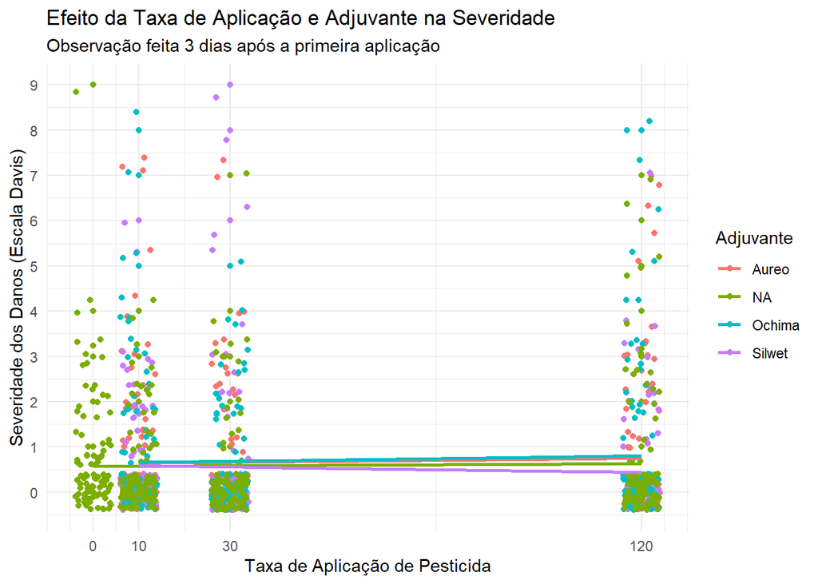

Com base nesses resultados, conseguimos fazer as interpretações necessárias.

No momento, estamos comparando esse método com outros de transformação da variável resposta para avaliar qual melhor explica os dados.